# District Level Report Patan

Author

Ayush Patel

Published

August 23, 2022

# Introduction - Patan

This report aims to provide a birds eye view of the district through the lens of village amenities data released by census in 2011. Before moving towards the descriptive insights from the census data, here is what pops up when a search is executed for Patan district Gujarat on wikipedia.

[interactive chart not shown]

# Summary Statistics

Total Number of Villages: 517  
Total Number of Gram Panchayat: 446  
Total Number of Sub Districts: 7  
Total Population : 1.062653^{6}

## Statistical Summaries at the subdistrict level

| Sub District | Total Population | Total SC Population | Total ST Population | Total Area of Vilalges | Total Area Sown (Net) |
| --- | --- | --- | --- | --- | --- |
| Chanasma | 114811 | 10147 | 222 | 43673.13 | 35545.36 |
| Harij | 74309 | 7035 | 24 | 37703.47 | 31891.71 |
| Patan | 315743 | 32459 | 1085 | 100412.69 | 73985.62 |
| Radhanpur | 104708 | 6443 | 2537 | 57188.32 | 38322.93 |
| Sami | 182805 | 16345 | 383 | 151464.97 | 106844.53 |
| Santalpur | 128791 | 8545 | 1350 | 135026.00 | 74697.36 |
| Sidhpur | 141486 | 15949 | 581 | 34671.23 | 26710.50 |

# Population and Geographical Area

It is of interest to look into which are the most densely populated villages. We can do this by creating a simple scatter plot between population of village and the total geographical area of a village.

[interactive chart not shown]

# Irrigation for Agriculture

The census provides the net area sown (hectares) in a village along with area irrigated with water source in hectares. The area under irrigation may be affected by several factors.

## Area Sown vs Area under Irrigation

[interactive chart not shown]

**A distribution for the percentage of area irrigated will be interesting to look at.**

[interactive chart not shown]

## Understanding what drives area under irrigation

Much is heard about rain fed agriculture in India. There are several factors that can affect area under irrigation - ranging from government supports, demographics, distance from urban clusters and several known and unknown variables. With the given data we can check if the following variables have any relation with area under irrigation:

- Percentage of Marginalised group population in village
- Distance from Major government offices
- Distance from urban center
- Total population of a village

**A simple Linear regression to see if the above explanation has any merit**

|  | *Dependent variable:* |
| --- | --- |
|  | perc_irrigated_over_net_sown |
| total_population_of_village | 0.0001 |
|  | (0.001) |
| perc_marginalised_pop | 0.032 |
|  | (0.105) |
| district_head_quarter_distance_in_km | -0.077 |
|  | (0.101) |
| sub_district_head_quarter_distance_in_km | 0.012 |
|  | (0.142) |
| nearest_statutory_town_distance_in_km | -0.250* |
|  | (0.147) |
| sub_district_nameHarij | -16.022*** |
|  | (4.343) |
| sub_district_namePatan | -1.962 |
|  | (3.632) |
| sub_district_nameRadhanpur | -42.032*** |
|  | (6.681) |
| sub_district_nameSami | -45.912*** |
|  | (4.412) |
| sub_district_nameSantalpur | -49.569*** |
|  | (7.878) |
| sub_district_nameSidhpur | -10.480*** |
|  | (4.029) |
| Constant | 73.589*** |
|  | (3.809) |
| Observations | 513 |
| R<sup>2</sup> | 0.591 |
| Adjusted R<sup>2</sup> | 0.582 |
| Residual Std. Error | 21.011 (df = 501) |
| F Statistic | 65.810*** (df = 11; 501) |
| *Note:* | *p<0.1; **p<0.05;*** p<0.01 |

### Model Diagnostic plots

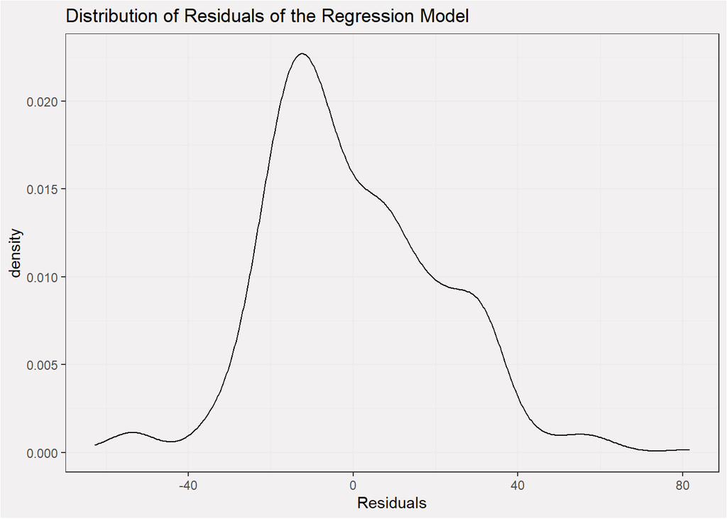

Distribution of Redsiduals

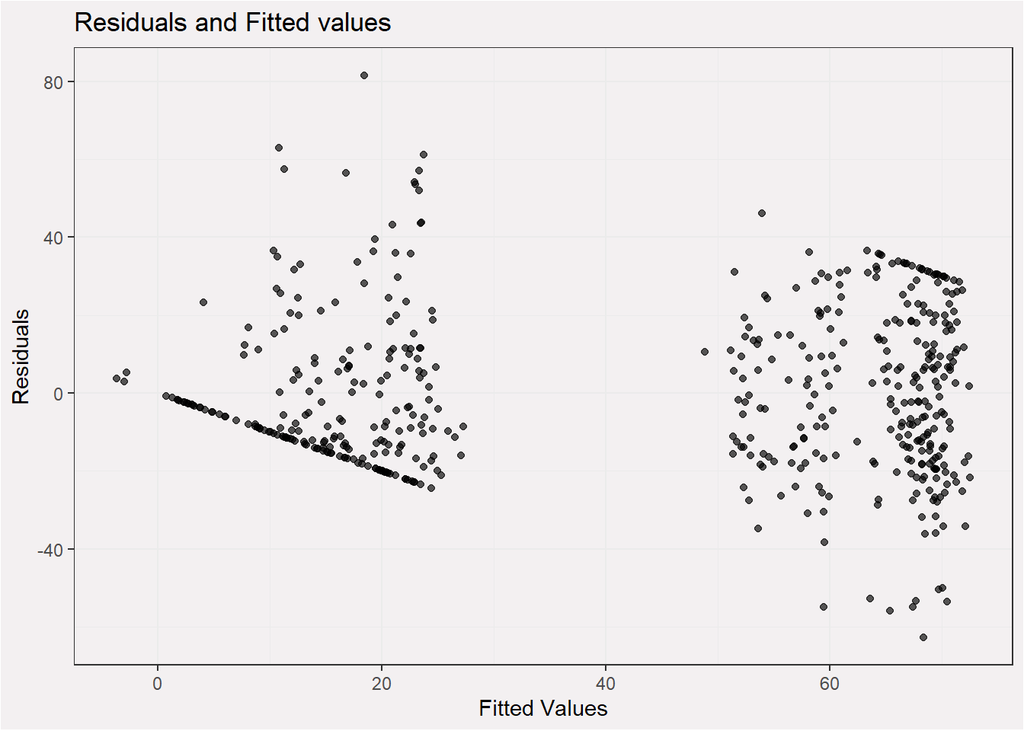

Residuals vs Fitted

# Note

This is to serve as a minimal example of creating parameterised reports with .rmd/.qmd files. This document is in no way analytically or statistically rigorous.